# Einkaufsgewohnheiten in den USA

Autor:in

Ole Kepa,  
Fabian Elsner,  
Sören Bax

Veröffentlichungsdatum

23. Dezember 2023

# 1 Gendererklärung

Aus Lesbarkeitsgründen wird in dieser Studienarbeit auf die verschiedene Ansprechweisen, sei es divers, männlich oder weiblich verzichtet. Alle Formulierungen sprechen gleichermaßen alle Geschlechter an.

# 2 Aufgabe und Daten verstehen

Hierzu steht ein Dataset zu dem Kaufverhalten von Verbrauchern in den USA zur Verfügung, das unter https://www.kaggle.com/datasets/zeesolver/consumer-behavior-and-shopping-habits-dataset/data abgerufen werden kann.

Dieses Datenset beinhaltet insgesamt zwei CSV-Dateien, welche sich jedoch nur in einem Spaltennamen und nicht in den Daten unterscheiden. Die Spalte zur Zahlungsmethode heißt in der Datei “shopping_behavior_updated.csv” “Payment_Method” und in der Datei “shopping_trend.csv” “Preferred Payment_Method”. Wir nutzen daher nur die CSV-Datei “shopping_behavior_updated.csv”.

## 2.1 Beschreibung der Datenquelle

Laden wir zuerst die Daten:

```r
raw_shopping_behavior <- read_csv('./data/shopping_behavior_updated.csv')
```

Nun werfen wir einen kurzen Blick auf die Daten und das Spaltenformat:

```r
knitr::kable(head(raw_shopping_behavior), caption = "Das Spaltenformat des Datensatzes 'shopping_behavior'")
```

Das Spaltenformat des Datensatzes 'shopping_behavior'

| Customer_ID | Age | Gender | Item_Purchased | Category | Purchase_Amount | Location | Size | Color | Season | Review_Rating | Subscription_Status | Shipping_Type | Discount_Applied | Promo_Code_Used | Previous_Purchases | Payment_Method | Frequency_of_Purchases |
| --- | --- | --- | --- | --- | --- | --- | --- | --- | --- | --- | --- | --- | --- | --- | --- | --- | --- |
| 1 | 55 | Male | Blouse | Clothing | 53 | Kentucky | L | Gray | Winter | 3.1 | Yes | Express | Yes | Yes | 14 | Venmo | Fortnightly |
| 2 | 19 | Male | Sweater | Clothing | 64 | Maine | L | Maroon | Winter | 3.1 | Yes | Express | Yes | Yes | 2 | Cash | Fortnightly |
| 3 | 50 | Male | Jeans | Clothing | 73 | Massachusetts | S | Maroon | Spring | 3.1 | Yes | Free Shipping | Yes | Yes | 23 | Credit Card | Weekly |
| 4 | 21 | Male | Sandals | Footwear | 90 | Rhode Island | M | Maroon | Spring | 3.5 | Yes | Next Day Air | Yes | Yes | 49 | PayPal | Weekly |
| 5 | 45 | Male | Blouse | Clothing | 49 | Oregon | M | Turquoise | Spring | 2.7 | Yes | Free Shipping | Yes | Yes | 31 | PayPal | Annually |
| 6 | 46 | Male | Sneakers | Footwear | 20 | Wyoming | M | White | Summer | 2.9 | Yes | Standard | Yes | Yes | 14 | Venmo | Weekly |

Jede Zeile steht für einen Einkauf. Die Spalten sind wie folgt definiert:

| Variable | Typ | Bedeutung |
| --- | --- | --- |
| **Customer_ID** | dbl | Eindeutige Kunden Identifikationsnummer |
| **Age** | dbl | Alter des Kundens |
| **Gender** | chr | Geschlecht des Kundens |
| **Item_Purchased** | chr | Gekauftes Produkt |
| **Category** | chr | Kategorie des gekauften Produkts |
| **Purchase_Amount** | dbl | Bezahlter Preis |
| **Location** | chr | Ort des Kaufes |
| **Size** | chr | Konfektionsgröße des gekauften Produkts |
| **Color** | chr | Farbe des gekauften Produkts |
| **Season** | chr | Jahreszeit, in welcher der Kauf getätigt wurde |
| **Review_Rating** | dbl | Kundenbewertungen zum Produkt |
| **Subscription_Status** | chr | Status des Abonnements |
| **Payment_Method** | chr | Zahlungsmethode |
| **Shipping_Type** | chr | Versandart |
| **Discount_Applied** | chr | Rabattcode genutzt? |
| **Promo_Code_Used** | chr | Werbecode genutzt? |
| **Previous_Purchases** | dbl | Anzahl vorheriger Käufe |
| **Payment_Method** | chr | Bevorzugte Zahlungsmethode |
| **Frequency_of_Purchases** | chr | Häufigkeit von Käufen |

```r
describe_tbl(raw_shopping_behavior)
```

```
3 900 (3.9k) observations with 18 variables
0 observations containing missings (NA)
0 variables containing missings (NA)
0 variables with no variance
```

Im Datensatz gibt es **3900** Instazen (Beobachtungen) und **18** Spalten. Die Daten sind bereits *tidy*, was bedeutet, dass jede Variable ihre eigene Spalte, jede Beobachtung seine eigene Zeile und jeder Wert seine eigene Zelle hat. Die Daten sind bereits *bereinigt*, was bedeutet, dass sie keine fehlenden Werte enthalten.

## 2.2 Thesen

# 3 Untersuchung der Daten

## 3.1 Untersuchung auf Außreißer

Um die Daten auf außreiser zu untersuchen schauen wir uns zunächst eine Zusammenfassung der Daten an:

```r
summary(raw_shopping_behavior)
```

```
  Customer_ID          Age           Gender          Item_Purchased
 Min.   :   1.0   Min.   :18.00   Length:3900        Length:3900
 1st Qu.: 975.8   1st Qu.:31.00   Class :character   Class :character
 Median :1950.5   Median :44.00   Mode  :character   Mode  :character
 Mean   :1950.5   Mean   :44.07
 3rd Qu.:2925.2   3rd Qu.:57.00
 Max.   :3900.0   Max.   :70.00
   Category         Purchase_Amount    Location             Size
 Length:3900        Min.   : 20.00   Length:3900        Length:3900
 Class :character   1st Qu.: 39.00   Class :character   Class :character
 Mode  :character   Median : 60.00   Mode  :character   Mode  :character
                    Mean   : 59.76
                    3rd Qu.: 81.00
                    Max.   :100.00
    Color              Season          Review_Rating  Subscription_Status
 Length:3900        Length:3900        Min.   :2.50   Length:3900
 Class :character   Class :character   1st Qu.:3.10   Class :character
 Mode  :character   Mode  :character   Median :3.70   Mode  :character
                                       Mean   :3.75
                                       3rd Qu.:4.40
                                       Max.   :5.00
 Shipping_Type      Discount_Applied   Promo_Code_Used    Previous_Purchases
 Length:3900        Length:3900        Length:3900        Min.   : 1.00
 Class :character   Class :character   Class :character   1st Qu.:13.00
 Mode  :character   Mode  :character   Mode  :character   Median :25.00
                                                          Mean   :25.35
                                                          3rd Qu.:38.00
                                                          Max.   :50.00
 Payment_Method     Frequency_of_Purchases
 Length:3900        Length:3900
 Class :character   Class :character
 Mode  :character   Mode  :character
```

```r
raw_shopping_behavior %>% describe()
```

```
# A tibble: 18 × 8
   variable               type     na na_pct unique   min    mean   max
   <chr>                  <chr> <int>  <dbl>  <int> <dbl>   <dbl> <dbl>
 1 Customer_ID            dbl       0      0   3900   1   1950.    3900
 2 Age                    dbl       0      0     53  18     44.1     70
 3 Gender                 chr       0      0      2  NA     NA       NA
 4 Item_Purchased         chr       0      0     25  NA     NA       NA
 5 Category               chr       0      0      4  NA     NA       NA
 6 Purchase_Amount        dbl       0      0     81  20     59.8    100
 7 Location               chr       0      0     50  NA     NA       NA
 8 Size                   chr       0      0      4  NA     NA       NA
 9 Color                  chr       0      0     25  NA     NA       NA
10 Season                 chr       0      0      4  NA     NA       NA
11 Review_Rating          dbl       0      0     26   2.5    3.75     5
12 Subscription_Status    chr       0      0      2  NA     NA       NA
13 Shipping_Type          chr       0      0      6  NA     NA       NA
14 Discount_Applied       chr       0      0      2  NA     NA       NA
15 Promo_Code_Used        chr       0      0      2  NA     NA       NA
16 Previous_Purchases     dbl       0      0     50   1     25.4     50
17 Payment_Method         chr       0      0      6  NA     NA       NA
18 Frequency_of_Purchases chr       0      0      7  NA     NA       NA
```

Die Customer_ID ist für Analysen nicht verwertbar. Wir können Sie im nächsten Schritt löschen.

## 3.2 Datenaufbereitung

Nun erstellen wir den finalen Datensatz, welcher die Basis für die weitere Analyse bildet. Zunächst löschen wir die Spalte “Customer_ID”, da diese für Analysen nicht verwertbar ist:

```r
shopping_behavior <- raw_shopping_behavior |> select(-"Customer_ID")
```

Werfen wir einen Blick auf das finale Datenset.

```r
knitr::kable(head(shopping_behavior), caption = "Das Spaltenformat des finalen Datensatzes")
```

Das Spaltenformat des finalen Datensatzes

| Age | Gender | Item_Purchased | Category | Purchase_Amount | Location | Size | Color | Season | Review_Rating | Subscription_Status | Shipping_Type | Discount_Applied | Promo_Code_Used | Previous_Purchases | Payment_Method | Frequency_of_Purchases |
| --- | --- | --- | --- | --- | --- | --- | --- | --- | --- | --- | --- | --- | --- | --- | --- | --- |
| 55 | Male | Blouse | Clothing | 53 | Kentucky | L | Gray | Winter | 3.1 | Yes | Express | Yes | Yes | 14 | Venmo | Fortnightly |
| 19 | Male | Sweater | Clothing | 64 | Maine | L | Maroon | Winter | 3.1 | Yes | Express | Yes | Yes | 2 | Cash | Fortnightly |
| 50 | Male | Jeans | Clothing | 73 | Massachusetts | S | Maroon | Spring | 3.1 | Yes | Free Shipping | Yes | Yes | 23 | Credit Card | Weekly |
| 21 | Male | Sandals | Footwear | 90 | Rhode Island | M | Maroon | Spring | 3.5 | Yes | Next Day Air | Yes | Yes | 49 | PayPal | Weekly |
| 45 | Male | Blouse | Clothing | 49 | Oregon | M | Turquoise | Spring | 2.7 | Yes | Free Shipping | Yes | Yes | 31 | PayPal | Annually |
| 46 | Male | Sneakers | Footwear | 20 | Wyoming | M | White | Summer | 2.9 | Yes | Standard | Yes | Yes | 14 | Venmo | Weekly |

# 4 Untersuchung der Thesen

Im folgenden werden die Thesen mit den Methoden der emplorativen Datenanalyse untersucht.

## 4.1 These 1:

## Die meisten Personen kaufen wöchentlich ein.

Es wird analysiert, wie oft Personen wöchentlich einkaufen, wobei der Fokus auf den verschiedenen Häufigkeiten liegt.

```r
frequency_counts <- shopping_behavior %>%
  count(`Frequency_of_Purchases`) %>%
  arrange(`Frequency_of_Purchases`)

frequency_counts %>%
  kable() %>%
  kable_styling(
    full_width = FALSE,
    position = "center",
    font_size = 16,
    latex_options = c("striped", "hold_position")
  ) %>%
  column_spec(1, color = "white")
```

| Frequency_of_Purchases | n |
| --- | --- |
| Annually | 572 |
| Bi-Weekly | 547 |
| Every 3 Months | 584 |
| Fortnightly | 542 |
| Monthly | 553 |
| Quarterly | 563 |
| Weekly | 539 |

Wir stellen diesse Daten im nächsten Schritt aufbereitet in einem Diagramm da

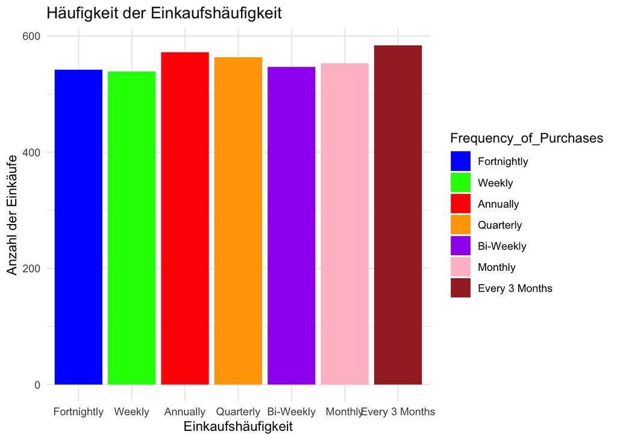

```r
frequency_mapping <- c("Fortnightly" = 2, "Weekly" = 1, "Annually" = 3,
                        "Quarterly" = 4, "Bi-Weekly" = 5, "Monthly" = 6, "Every 3 Months" = 7)
frequency_colors <- c("Fortnightly" = "blue", "Weekly" = "green", "Annually" = "red",
                      "Quarterly" = "orange", "Bi-Weekly" = "purple", "Monthly" = "pink", "Every 3 Months" = "brown")

shopping_behavior$`Frequency_of_Purchases` <- factor(shopping_behavior$`Frequency_of_Purchases`, levels = names(frequency_mapping))

unique_values <- unique(shopping_behavior$`Frequency_of_Purchases`)


ggplot(shopping_behavior, aes(x = `Frequency_of_Purchases`, fill = `Frequency_of_Purchases`)) +
  geom_bar(stat = "count") +
  labs(title = "Häufigkeit der Einkaufshäufigkeit", x = "Einkaufshäufigkeit", y = "Anzahl der Einkäufe") +
  scale_fill_manual(values = frequency_colors) +
  theme_minimal()
```

```r
# Den höchsten Wert aller Einkaufshäufigkeiten ermitteln
max_count_freq <- max(frequency_counts$n)
```

Wir sehen, dass die meisten Personen “Every 3 Months” einkaufen, mit einer Häufigkeit von 584. Sommit wurde die erste These wiederlegt.

## 4.2 These 2:

## Die meisten Klamotten sind in den Farben Schwarz, Weiß oder Grau.

Zuerst schauen wir, welche Farben alle vorhanden sind.

```r
rows <- nrow(shopping_behavior |> distinct(Color))
print(shopping_behavior |> distinct(Color), n = rows)
```

```
# A tibble: 25 × 1
   Color
   <chr>
 1 Gray
 2 Maroon
 3 Turquoise
 4 White
 5 Charcoal
 6 Silver
 7 Pink
 8 Purple
 9 Olive
10 Gold
11 Violet
12 Teal
13 Lavender
14 Black
15 Green
16 Peach
17 Red
18 Cyan
19 Brown
20 Beige
21 Orange
22 Indigo
23 Yellow
24 Magenta
25 Blue
```

Wir sehen, dass es 25 Farben gibt. Nun schauen wir uns die Häufigkeit der Farben an:

```r
rows <- nrow(shopping_behavior |> distinct(Color))
print(shopping_behavior |> count(Color) |> arrange(desc(n)) , n = rows)
```

```
# A tibble: 25 × 2
   Color         n
   <chr>     <int>
 1 Olive       177
 2 Yellow      174
 3 Silver      173
 4 Teal        172
 5 Green       169
 6 Black       167
 7 Cyan        166
 8 Violet      166
 9 Gray        159
10 Maroon      158
11 Orange      154
12 Charcoal    153
13 Pink        153
14 Blue        152
15 Magenta     152
16 Purple      151
17 Peach       149
18 Red         148
19 Beige       147
20 Indigo      147
21 Lavender    147
22 Turquoise   145
23 White       142
24 Brown       141
25 Gold        138
```

Nun schauen wir uns die Häufigkeit der Farben an, die nicht Schwarz, Weiß oder Grau sind:

```r
rows <- nrow(shopping_behavior |> distinct(Color))
print(shopping_behavior |> filter(Color != "Black" & Color != "White" & Color != "Gray") |> count(Color) |> arrange(desc(n)) , n = rows)
```

```
# A tibble: 22 × 2
   Color         n
   <chr>     <int>
 1 Olive       177
 2 Yellow      174
 3 Silver      173
 4 Teal        172
 5 Green       169
 6 Cyan        166
 7 Violet      166
 8 Maroon      158
 9 Orange      154
10 Charcoal    153
11 Pink        153
12 Blue        152
13 Magenta     152
14 Purple      151
15 Peach       149
16 Red         148
17 Beige       147
18 Indigo      147
19 Lavender    147
20 Turquoise   145
21 Brown       141
22 Gold        138
```

```r
result <- shopping_behavior %>%
  count(Color) %>%
  mutate(Percentage = n / sum(n) * 100) %>%
  filter(Color %in% c("Black", "Gray", "White")) %>%
  arrange(desc(Percentage)) %>%
  mutate(Cumulative_Percentage = cumsum(Percentage)) %>%
  summarize(
    Gesamtanteil = sum(Percentage),
    Anteil_Schwarz = sum(Percentage[Color == "Black"]),
    Anteil_Grau = sum(Percentage[Color == "Gray"]),
    Anteil_Weiß = sum(Percentage[Color == "White"]),
    Kumulierter = max(Cumulative_Percentage)
  )

print(result)
```

```
# A tibble: 1 × 5
  Gesamtanteil Anteil_Schwarz Anteil_Grau Anteil_Weiß Kumulierter
         <dbl>          <dbl>       <dbl>       <dbl>       <dbl>
1           12           4.28        4.08        3.64          12
```

Dies zeigt uns, dass die These, dass die Farben Schwarz, Grau und Weiß am häufigsten gekauft werden, nicht stimmt. Zur verdeutlichung wird ein Balkendiagramm erstellt.

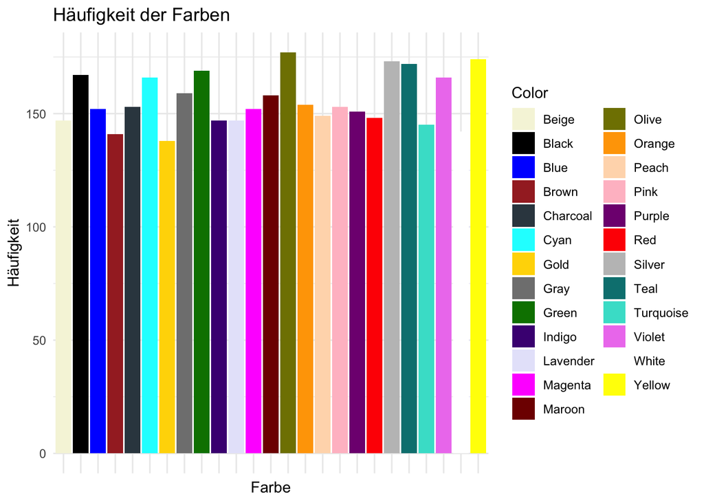

```r
data <- shopping_behavior %>%
  count(Color)

color_palette <- c(
  "Gray" = "#808080",
  "Maroon" = "#800000",
  "Turquoise" = "#40E0D0",
  "White" = "#FFFFFF",
  "Charcoal" = "#36454F",
  "Silver" = "#C0C0C0",
  "Pink" = "#FFC0CB",
  "Purple" = "#800080",
  "Olive" = "#808000",
  "Gold" = "#FFD700",
  "Violet" = "#EE82EE",
  "Teal" = "#008080",
  "Lavender" = "#E6E6FA",
  "Black" = "#000000",
  "Green" = "#008000",
  "Peach" = "#FFDAB9",
  "Red" = "#FF0000",
  "Cyan" = "#00FFFF",
  "Brown" = "#A52A2A",
  "Beige" = "#F5F5DC",
  "Orange" = "#FFA500",
  "Indigo" = "#4B0082",
  "Yellow" = "#FFFF00",
  "Magenta" = "#FF00FF",
  "Blue" = "#0000FF"
)

ggplot(data, aes(x = Color, y = n, fill = Color)) +
  geom_bar(stat = "identity") +
  labs(title = "Häufigkeit der Farben", x = "Farbe", y = "Häufigkeit") +
  scale_fill_manual(values = color_palette) +
  theme_minimal() +
  theme(axis.text.x = element_blank())
```

```r
# Den höchsten Wert aller Farben ermitteln
max_count <- max(data$n)
```

Wir sehen, dass die Farbe Olive am häufigsten gekauft wird, mit einer Stückzahl von 177. Somit lässt sich die These wiederlegen.

## 4.3 These 3:

## Die meisten Kunden zahlen Bar.

Wir betrachten die verscheidenen Bezahlarten

```r
unique_payment_methods <- unique(shopping_behavior$`Payment_Method`)
cat("Zahlungsmethoden:", toString(unique_payment_methods), "\n")
```

```
Zahlungsmethoden: Venmo, Cash, Credit Card, PayPal, Bank Transfer, Debit Card
```

Wir schauen uns an, wie viele Zahlungen Bar getätigt wurden

```r
count_cash_payments <- sum(shopping_behavior$`Payment_Method` %in% c("Bar", "Cash"), na.rm = TRUE)
cat("Anzahl der Barzahlungen:", count_cash_payments, "\n")
```

```
Anzahl der Barzahlungen: 670
```

Wir zeigen den prozentualen Anteil der Barzahlungen an allen Zahlungen

```r
percentage_cash <- count_cash_payments / nrow(shopping_behavior) * 100
cat("Prozentsatz der Barzahlungen:", percentage_cash, "%\n")
```

```
Prozentsatz der Barzahlungen: 17.17949 %
```

Anzahl aller Zahlungen

```r
total_payments <- nrow(raw_shopping_behavior)

cat("Alle Zahlungen :", total_payments)
```

```
Alle Zahlungen : 3900
```

Für eine gute Analyse der Werte, schauen wir uns alle Bezahlmethoden an

```r
payment_data <- raw_shopping_behavior %>%
  group_by(`Payment_Method`) %>%
  summarise(TotalAmount = sum(`Purchase_Amount`)) %>%
  ungroup() %>%
  mutate(Percentage = TotalAmount / sum(TotalAmount) * 100)

payment_data %>%
  select(`Payment_Method`, Percentage)
```

```
# A tibble: 6 × 2
  Payment_Method Percentage
  <chr>               <dbl>
1 Bank Transfer        15.7
2 Cash                 17.2
3 Credit Card          17.3
4 Debit Card           16.6
5 PayPal               17.2
6 Venmo                16.0
```

```r
# Den höchsten Wert aller Zahlungsmethoden ermitteln und den Prozentwert auf 2 Nachkommastellen runden
max_percentage_payment <- max(payment_data$Percentage)
max_percentage_payment_rounded <- round(max_percentage_payment, 2)
```

Wir sehen, dass die meisten Kunden via “Credit Card” zahlen, mit einem Anteil von 17.29 % an allen Zahlungen.

## 4.7 These 7:

## Die meisten Klamotten werden im Norden gekauft.

Zunächst schauen wir uns einmal alle vorhandenen Orte an:

```r
shopping_behavior |> distinct(Location)
```

```
# A tibble: 50 × 1
   Location
   <chr>
 1 Kentucky
 2 Maine
 3 Massachusetts
 4 Rhode Island
 5 Oregon
 6 Wyoming
 7 Montana
 8 Louisiana
 9 West Virginia
10 Missouri
# ℹ 40 more rows
```

Wir sehen, dass es 50 Orte gibt. Nun schauen wir uns die Häufigkeit der einzelnen Orte an:

```r
rows <- nrow(shopping_behavior |> distinct(Location))
print(shopping_behavior |> count(Location) |> arrange(desc(n)) , n = rows)
```

```
# A tibble: 50 × 2
   Location           n
   <chr>          <int>
 1 Montana           96
 2 California        95
 3 Idaho             93
 4 Illinois          92
 5 Alabama           89
 6 Minnesota         88
 7 Nebraska          87
 8 Nevada            87
 9 New York          87
10 Delaware          86
11 Maryland          86
12 Vermont           85
```

[output cut: 38 more lines]

Nun erstellen wir eine Heatmap über die Häufigkeit der Orte:

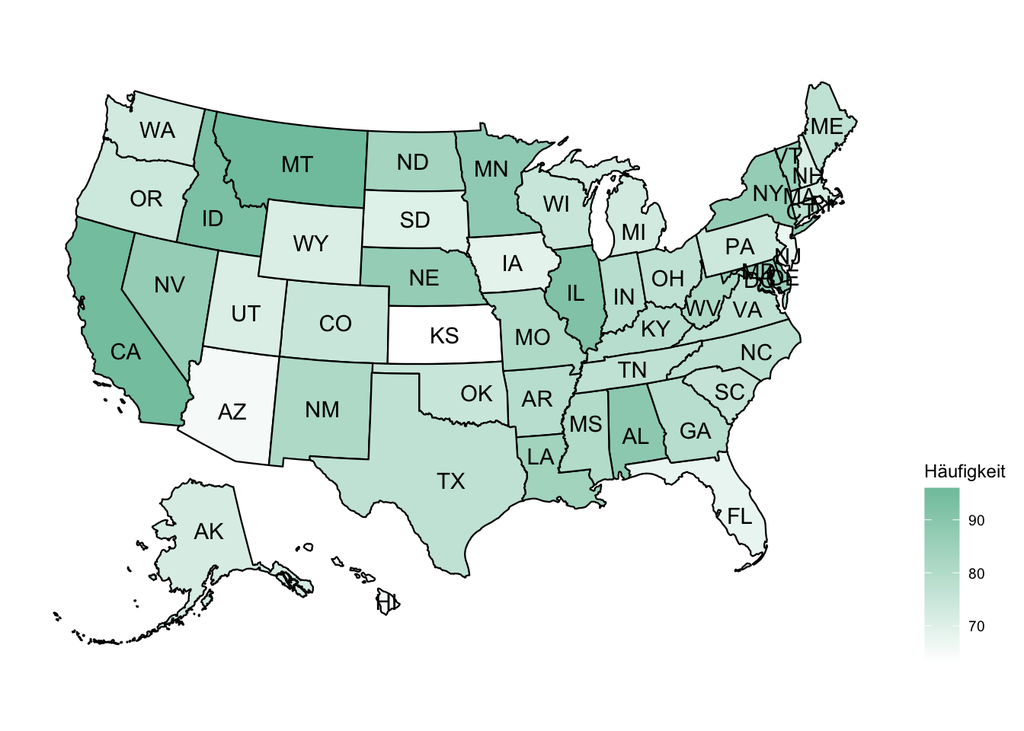

```r
# Werte aus der Tabelle shopping_behavior übernommen
df <- data.frame(
  state  = c("Montana", "California", "Idaho", "Illinois", "Alabama", "Minnesota", "Nebraska", "Nevada", "New York", "Delaware",
             "Maryland", "Vermont", "Louisiana", "North Dakota", "Missouri", "New Mexico", "West Virginia","Mississippi", "Arkansas", "Georgia",
             "Indiana", "Kentucky", "Connecticut", "North Carolina", "Maine", "Ohio", "Tennessee", "Texas", "Virginia", "South Carolina",
             "Colorado", "Oklahoma", "Wisconsin", "Oregon", "Pennsylvania", "Michigan", "Washington", "Alaska", "Massachusetts", "New Hampshire",
             "New Hampshire", "Utah", "Wyoming", "South Dakota", "Iowa", "Florida", "New Jersey", "Arizona", "Hawaii", "Kansas",
             "Rhode Island"),
  occurrence = c(96, 95, 93, 92, 89, 88, 87, 87, 87, 86,
                 86, 85, 84, 83, 81, 81, 81, 80, 79, 79,
                 79, 79, 78, 78, 77, 77, 77, 77, 77, 76,
                 75, 75, 75, 74, 74, 73, 73, 72, 72, 71,
                 71, 71, 71, 70, 69, 68, 67, 65, 65, 63,
                 63)
)

plot_usmap(data = df, values = "occurrence", color = "black", labels = TRUE) +
  scale_fill_continuous(
    low = "white", high = "#80c4ac", name = "Häufigkeit", label = scales::comma
  ) + theme(legend.position = "right")
```

## 4.8 These 8:

[output not shown]

Zunächst schauen wir uns einmal alle vorhandenen Kategorien an:

```r
shopping_behavior |> distinct(Category)
```

```
# A tibble: 4 × 1
  Category
  <chr>
1 Clothing
2 Footwear
3 Outerwear
4 Accessories
```

Wir sehen, dass es 4 Kategorien gibt: Klamotten, Schuhe, Accessoires und Oberbekleidung Nun schauen wir uns die Häufigkeit der Kategorien an:

```r
shopping_behavior |> count(Category)
```

```
# A tibble: 4 × 2
  Category        n
  <chr>       <int>
1 Accessories  1240
2 Clothing     1737
3 Footwear      599
4 Outerwear     324
```

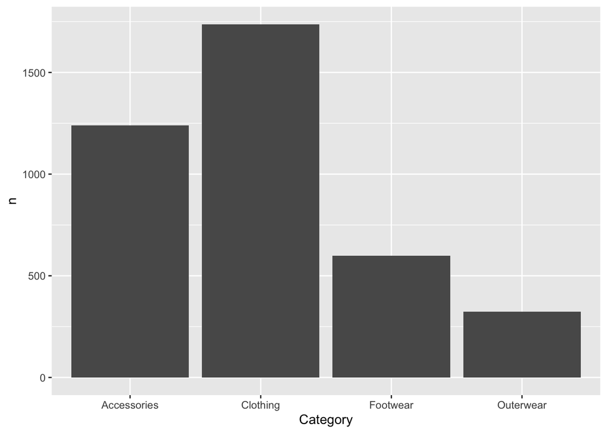

```r
shopping_behavior |> count(Category) |> ggplot(aes(x = Category, y = n)) + geom_col()
```

Wir sehen, dass die Kategorie “Klamotten” mit 1737 Instanzen am häufigsten vorkommt.Danach folgt die Kategorie “Accessoires” mit 1240 Instanzen. Am seltensten kommen die Kategorien “Schuhe” mit 599 und “Oberbekleidung” mit 324 Instanzen vor.

## 4.9 These 9:

## Es kaufen mehr Personen über 40 Jahre ein, als Personen unter 40 Jahren.

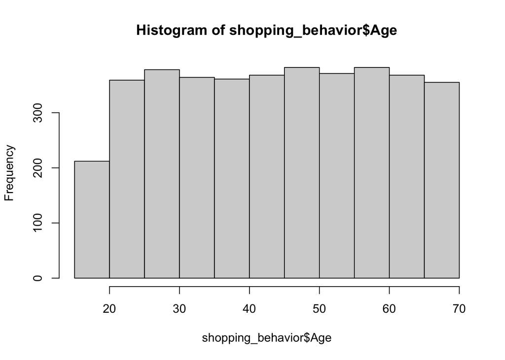

```r
hist(shopping_behavior$Age)
```

Einkauf mit dem höchsten Alter:

```r
shopping_behavior |> arrange(desc(Age)) |> head(1)
```

```
# A tibble: 1 × 17
    Age Gender Item_Purchased Category Purchase_Amount Location Size  Color
  <dbl> <chr>  <chr>          <chr>              <dbl> <chr>    <chr> <chr>
1    70 Male   Pants          Clothing              60 Arizona  S     Turquoise
# ℹ 9 more variables: Season <chr>, Review_Rating <dbl>,
#   Subscription_Status <chr>, Shipping_Type <chr>, Discount_Applied <chr>,
#   Promo_Code_Used <chr>, Previous_Purchases <dbl>, Payment_Method <chr>,
#   Frequency_of_Purchases <fct>
```

Einkauf mit dem niedrigsten Alter:

```r
shopping_behavior |> arrange(Age) |> head(1)
```

```
# A tibble: 1 × 17
    Age Gender Item_Purchased Category  Purchase_Amount Location Size  Color
  <dbl> <chr>  <chr>          <chr>               <dbl> <chr>    <chr> <chr>
1    18 Male   Jacket         Outerwear              22 Florida  M     Green
# ℹ 9 more variables: Season <chr>, Review_Rating <dbl>,
#   Subscription_Status <chr>, Shipping_Type <chr>, Discount_Applied <chr>,
#   Promo_Code_Used <chr>, Previous_Purchases <dbl>, Payment_Method <chr>,
#   Frequency_of_Purchases <fct>
```

Berechnen wir Mittelwert und Median.

```r
shopping_behavior |> summarise(mean(Age), median(Age))
```

```
# A tibble: 1 × 2
  `mean(Age)` `median(Age)`
        <dbl>         <dbl>
1        44.1            44
```

```r
mean_behavior <- as.double(mean(shopping_behavior$Age))
med_behavior <- as.integer(median(shopping_behavior$Age))
```

Die Spannweite des Alters ist:

```r
max(shopping_behavior$Age) - min(shopping_behavior$Age)
```

```
[1] 52
```

Nun erstellen wir einen Boxplot für das Alter:

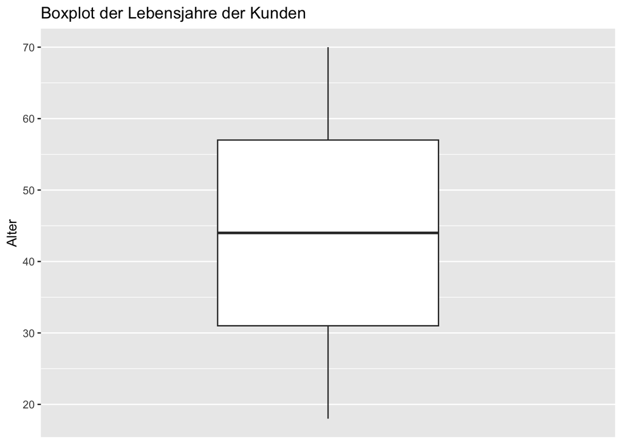

```r
ggplot(shopping_behavior, aes(x = Age)) +
  geom_boxplot() +
  coord_flip() +
  labs(
    x = "Alter",
    title = "Boxplot der Lebensjahre der Kunden",
  ) +
  scale_y_discrete(labels = NULL, breaks = NULL)  +
  scale_x_continuous(
    labels = comma_format(big.mark = ".",
                          decimal.mark = ","))
```

# 5 Anwendung und Beurteilung von Machine-Learning-Modellen

## 5.1 Modell 1 (Ole)

### 5.1.1 Anwendung

Wir analysieren die Daten mit Hilfe von lineare Regression. Wir wollen vorhersagen, wie viele Einkäufe es in den einzelnen Altersgruppen geben wird. Dafür erstellen wir ein Modell.

Daten gruppieren und Zusammenzählen

```r
# Daten gruppieren und die Anzahl der Einkäufe pro Altersgruppe zusammenzählen
purchase_count_by_age <- shopping_behavior %>%
  group_by(Age) %>%
  summarize(Total_Purchases = n())

print(purchase_count_by_age)
```

```
# A tibble: 53 × 2
     Age Total_Purchases
   <dbl>           <int>
 1    18              69
 2    19              81
 3    20              62
 4    21              69
 5    22              66
 6    23              71
 7    24              68
 8    25              85
 9    26              69
10    27              83
# ℹ 43 more rows
```

Daten aufteilen und Modell erstellen

```r
# Modell erstellen (lineare Regression)
linear_model <- lm(Total_Purchases ~ Age, data = purchase_count_by_age)

print(linear_model)
```

```
Call:
lm(formula = Total_Purchases ~ Age, data = purchase_count_by_age)

Coefficients:
(Intercept)          Age
   72.63764      0.02153
```

Vorhersagen mit Testdaten

```r
# Vorhersagen für alle Altersgruppen im vorhandenen Datenbereich
age_range <- seq(min(purchase_count_by_age$Age), max(purchase_count_by_age$Age), length.out = 10)
predictions <- predict(linear_model, newdata = data.frame(Age = age_range), interval = "confidence")

# Spalten umbenennen und auf 2 Nachkommastellen runden
colnames(predictions) <- c("Vorhergesagte Einkäufe", "Unteres Konfidenzintervall", "Oberes Konfidenzintervall")
predictions <- round(predictions, 2)

# Tabelle anzeigen
print(predictions)
```

```
   Vorhergesagte Einkäufe Unteres Konfidenzintervall Oberes Konfidenzintervall
1                   73.03                      68.78                     77.27
2                   73.15                      69.58                     76.72
3                   73.27                      70.31                     76.24
4                   73.40                      70.92                     75.87
5                   73.52                      71.33                     75.71
6                   73.65                      71.46                     75.84
7                   73.77                      71.30                     76.25
8                   73.90                      70.93                     76.86
9                   74.02                      70.45                     77.59
10                  74.14                      69.90                     78.39
```

Daten gruppieren und Vorhersagen zusammenzählen:

```r
# Daten für den Plot vorbereiten und auf 2 nachkommastellen runden
plot_data <- data.frame(Age = age_range, Predicted_Purchases = predictions[, 1],
                        Lower = predictions[, 2], Upper = predictions[, 3]) %>%
  mutate(Age = round(Age, 2), Predicted_Purchases = round(Predicted_Purchases, 2),
         Lower = round(Lower, 2), Upper = round(Upper, 2))



# Tabelle anzeigen
print(plot_data)
```

```
     Age Predicted_Purchases Lower Upper
1  18.00               73.03 68.78 77.27
2  23.78               73.15 69.58 76.72
3  29.56               73.27 70.31 76.24
4  35.33               73.40 70.92 75.87
5  41.11               73.52 71.33 75.71
6  46.89               73.65 71.46 75.84
7  52.67               73.77 71.30 76.25
8  58.44               73.90 70.93 76.86
9  64.22               74.02 70.45 77.59
10 70.00               74.14 69.90 78.39
```

Scatterplot mit Konfidenzintervall erstellen

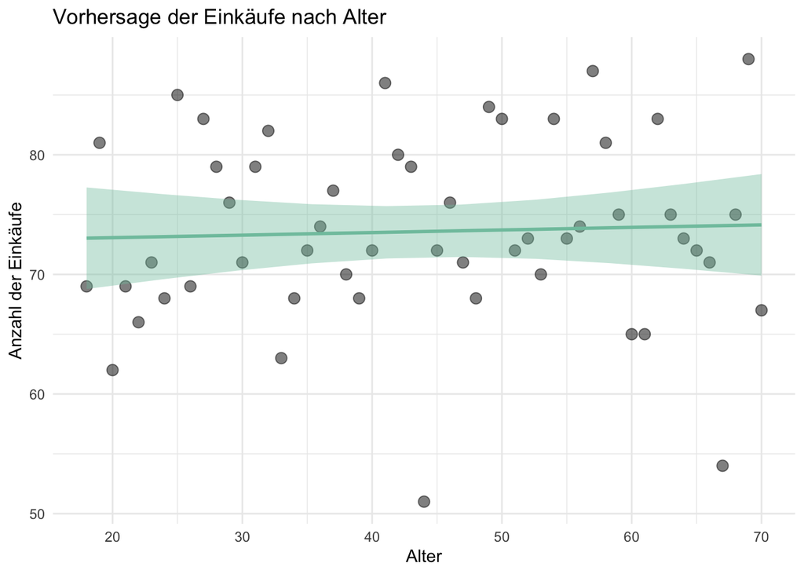

```r
# Scatterplot mit Konfidenzintervall erstellen
ggplot() +
  geom_point(data = purchase_count_by_age, aes(x = Age, y = Total_Purchases), color = "black", size = 3, alpha = 0.5) +
  geom_line(data = plot_data, aes(x = Age, y = Predicted_Purchases), color = "#80c4ac", linewidth = 1) +
  geom_ribbon(data = plot_data, aes(x = Age, ymin = Lower, ymax = Upper), fill = "#80c4ac", alpha = 0.4) +
  labs(
    title = "Vorhersage der Einkäufe nach Alter",
    x = "Alter",
    y = "Anzahl der Einkäufe"
  ) +
  theme_minimal()
```

## 5.2 Modell 2 (Ole)

Vorhersage des Discount_Applied (Rabattcode genutzt) basierend auf dem Kaufbetrag (Purchase_Amount) und der vorherigen Anzahl von Käufen (Previous_Purchases).

Aufbereitung der Testdaten und deren Ausgabe. Die Daten werden in Trainings- und Testdaten aufgeteilt. Die Trainingsdaten werden für das Modell verwendet und die Testdaten für die Vorhersage.

```r
shopping_behavior$Discount_Applied <- as.factor(shopping_behavior$Discount_Applied)

# Daten aufteilen
set.seed(123)
training_rows <- sample(1:nrow(shopping_behavior), 0.8 * nrow(shopping_behavior))
training_data <- shopping_behavior[training_rows, ]
test_data <- shopping_behavior[-training_rows, ]

# Modell erstellen (logistische Regression)
logistic_model <- glm(Discount_Applied ~ Purchase_Amount + Previous_Purchases, data = training_data, family = "binomial")

# Vorhersagen für Testdaten
predictions <- predict(logistic_model, newdata = test_data, type = "response")

# Vorhersagen in Tabelle zusammenfassen
prediction_table <- data.frame(Discount_Applied = test_data$Discount_Applied, Predicted_Probability = predictions)

# Tabelle ausgeben mit 10 ergebnissen und vermerken, dass es mehr gibt.
print(head(prediction_table, 10))
```

```
   Discount_Applied Predicted_Probability
1               Yes             0.4250493
2               Yes             0.4333789
3               Yes             0.4383641
4               Yes             0.4275015
5               Yes             0.4103624
6               Yes             0.4526143
7               Yes             0.4472316
8               Yes             0.4434892
9               Yes             0.4443885
10              Yes             0.4227223
```

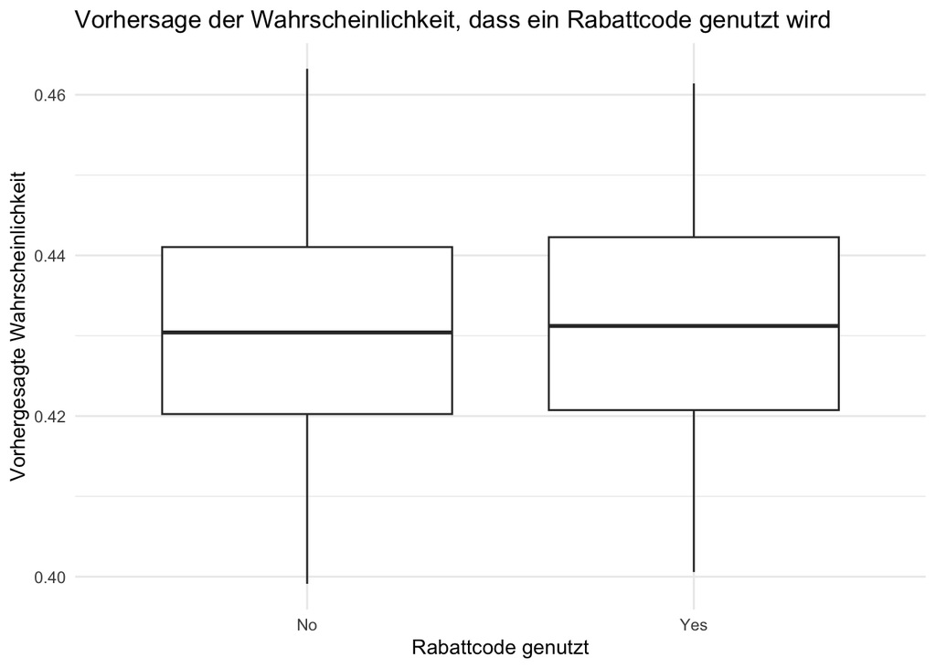

```r
# visuelle Darstellung der Vorhersagen
ggplot(prediction_table, aes(x = Discount_Applied, y = Predicted_Probability)) +
  geom_boxplot() +
  labs(
    title = "Vorhersage der Wahrscheinlichkeit, dass ein Rabattcode genutzt wird",
    x = "Rabattcode genutzt",
    y = "Vorhergesagte Wahrscheinlichkeit"
  ) +
  theme_minimal()
```

Kommulierte Ausgabe der Warscheinlichkeiten, dass ein Rabattcode genutzt wird oder nicht (als Wert zwischen 0 und 1).

```r
cumulative_prediction_table <- prediction_table %>%
  group_by(Discount_Applied) %>%
  summarize(Distribution = mean(Predicted_Probability))


colnames(cumulative_prediction_table) <- c("Rabatt Angewandt", "Prognostizierte Wahrscheinlichkeit")


print(cumulative_prediction_table)
```

```
# A tibble: 2 × 2
  `Rabatt Angewandt` `Prognostizierte Wahrscheinlichkeit`
  <fct>                                             <dbl>
1 No                                                0.430
2 Yes                                               0.431
```

## 5.6 Modell 6 (Sörn)

```r
names(shopping_behavior)
```

```
 [1] "Age"                    "Gender"                 "Item_Purchased"
 [4] "Category"               "Purchase_Amount"        "Location"
 [7] "Size"                   "Color"                  "Season"
[10] "Review_Rating"          "Subscription_Status"    "Shipping_Type"
[13] "Discount_Applied"       "Promo_Code_Used"        "Previous_Purchases"
[16] "Payment_Method"         "Frequency_of_Purchases"
```

```r
sum(is.na(shopping_behavior))
```

```
[1] 0
```

### 5.6.1 Anwendung

### 5.6.2 Beurteilung

# 6 Fazit

## 6.1 Bewertung

Ich finde das sehr Kritisch und nicht schön

## 6.2 Ideen für weitere Analysen

# 7 Quellen

Datenset: https://www.kaggle.com/datasets/zeesolver/consumer-behavior-and-shopping-habits-dataset/data  
US-Map: https://jtr13.github.io/cc19/different-ways-of-plotting-u-s-map-in-r.html  
US-Map 2: https://cran.r-project.org/web/packages/usmap/vignettes/mapping.html

# 8 Ehrenwörtliche Erklärung

Hiermit erklären wir, dass wir die vorliegende Studienarbeit (Produktstudie) selbständig angefertigt haben und die Bearbeiter der einzelnen Abschnitte wahrheitsgemäß angegeben haben. Es wurden nur die in der Arbeit ausdrücklich benannten Quellen und Hilfsmittel benutzt. Wörtlich oder sinngemäß übernommenes Gedankengut haben wir als solches kenntlich gemacht. Diese Arbeit hat in gleicher oder ähnlicher Form ganz oder teilweise noch keiner Prüfungsbehörde vorgelegen.

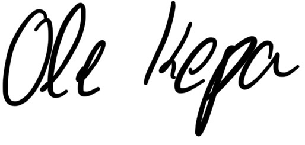

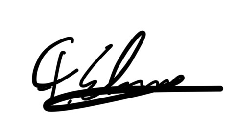

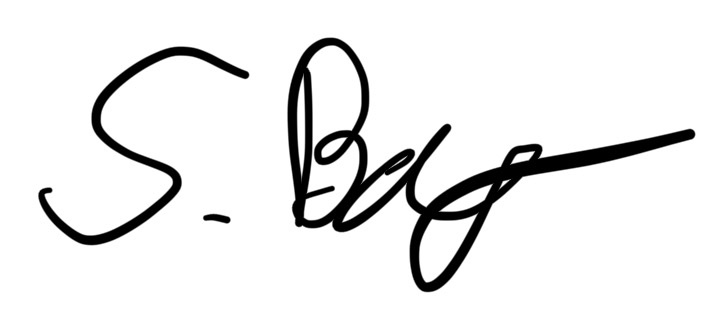